# matlpotlib_ttutorial

In the following section, we will be looking at three sample of libaries used for plotting graphs.

| library Name | module Name |
| --- | --- |
| matplotlib | pyplot |
| plotly | express |
| seaborn | seaborn |

## matplotlib

> The code makes use of the [pyplot](https://matplotlib.org/stable/tutorials/pyplot.html) module in the [matplotlib](https://matplotlib.org/stable/)

```python
import matplotlib as mpl
import matplotlib.pyplot as plt
```

- we start with creating the axes and then plot varies point on the axis by providing **two equal** list, one for the *x axis* and the other is for the *y axis*. Then the first element in the x axist and the first element in the y axis makes the first cordinate in the graph.

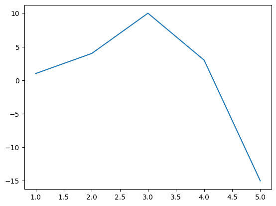

```python
fig, ax = plt.subplots()  # Create a figure containing a single axes.
ax.plot([1, 2, 3, 4,5], [1, 4, 10, 3,-15])  # Plot some data on the axes.
```

## plotly

- In this example, we will make use of the `plotly express` library. One of the many sample data sets available is the **iris flower**.

[figure not shown]

The `scatter` function take the following arguments:

1. Data Frame (object to be ploted)
2. x and y cordinate, in this sample, I am passing the sepal width and hight.
3. color: color the points based on the species
4. size: petal length
5. hover_data: using the pedal width as the value to be shown when hoving over the data point.

```python
import plotly.express as px
df = px.data.iris()
fig = px.scatter(df, x="sepal_width", y="sepal_length", color="species",
                 size='petal_length', hover_data=['petal_width'])
fig.show()
```

## seaborn

The **seaborn** library is similar to *plotly express* in the sense you also select a *dataset*, and then you load it into the line plot along with:

- x and y coordinates (in this example, the `timepoint` and `signal`)
- hue: considering the `region`,
- style: the events

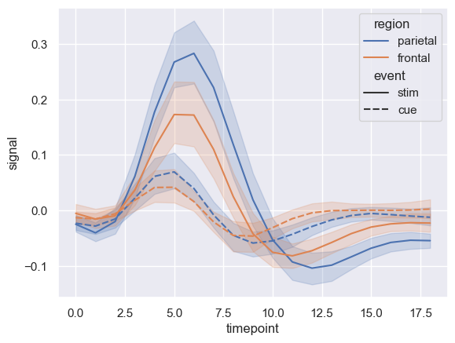

```python
import seaborn as sns
sns.set_theme(style="darkgrid")

# Load an example dataset with long-form data
fmri = sns.load_dataset("fmri")

# Plot the responses for different events and regions
sns.lineplot(x="timepoint", y="signal",
             hue="region", style="event",
             data=fmri)
```